# Project_1_draft_2-Copy1

```python
import numpy as np
import matplotlib.pyplot as plt
import math
```

## Problem:

Suppose that we found a volatile substance that we have placed in a sealed container. We know that molecules leave the surface at a rate 5 times the area of the surface and return at a rate 3 times the amount which has evaporated. Assume that this substance is spread evenly to a depth of 2mm over the bottom of a closed box that is 10cm by 5cm. Find a equation to model the depth of the substance at any point in time. Time is in hours.

## Creating a Differential Equation to Model Height

Let $V(t)$ be some function that gives volume of the substance remaining in the dish at $t$ hours. The rate of change of this function may be expressed as the difference between the rate of condensation and the rate of evaporation, which are expressed in the problem statement. By substitution:

$\frac{dV}{dt} = 3($amount evaporated$)-5($surface area$)$

The amount evaporated may be expressed as the difference between the initial volume and the volume at some time, $V_0-V(t)$. By noting constants of the initial volume, $10$ cm$^3$, and surface area, $50$ cm$^2$, a volume differential may be obtained:

$\frac{dV}{dt} = 3(10-V)-5(50)$  
$\frac{dV}{dt} = -220-3V$

By expressing volume as the product of height and surface area, and treating each parameter as a function of time, an equation relating height and volume may be obtained. Differentiating this equation, and noting that surface area is constant, reveals a height function and a volume function that are linearly related by a scalar introduced through a constant surface area:

$V = H*S$  
$V'=H'\cdot S + H \cdot S'$

$V'\cdot \frac{1}{S}=H'$

By distributing this scalar through the initial differential equation, a height differential $H'$ can be obtained:

$H' = \frac{-220}{50} - 3H$

Using an integrating factor, it is possible to obtain a general solution:

$\frac{d}{dt}(He^{3t})=\frac{-22}{5}e^{3t}$  
$He^{3t}=\int \frac{-22}{5}e^{3t}$  
$H=\frac{-22}{15}+Ce^{-3t}$

Using the initial value $H(0)=0.2$ cm, a particular solution may be obtained:

$0.2=\frac{-22}{15}+Ce^{-3(0)}$  
$C=\frac{5}{3}$  
$H=\frac{-22}{15}+\frac{5}{3}e^{-3t}$

This specific solution $H(t)$ outputs the height, in cm, of the substance remaining in the dish at $t$ hours.

## Solution Plot:

First, all necessary constants are set, and a function is defined from the manually determined solution. This function is $H(t)$.

```python
# calculated or constraint constants
x_i = 0                # the initial value input
y_i = 0.2              # the initial value output
step_size = 0.01       # the x step between y values for euler

# experimental constants
resolution = 0.0001    # the x step between directly calculated values
start_point = 0        # start calculating at this x value
end_point = 0.11       # stop calculating at this x value
```

```python
def h(x):
    return (-22/15) + (5/3) * np.e ** (-3*x)
```

Next, $H(t)$ is calculated and plotted directly.

[figure not shown]

```python
t = np.arange(start_point, end_point, resolution)

plt.title('Depth of Solution by Direct Computation')
plt.xlabel('Time (hours)')
plt.ylabel('Depth (mm)')
plt.plot(t, h(t))
```

This approximation is performed by Eulers method. In this method, an initial value and a differential equation which may provide slope are used. A slope is calculated at the initial value, then the independent variable is advanced by some small value, at which point the slope is calculated again. In this way, the output of the function may be approximated with only linear calculations.

First, the differential is defined. This is the function which will be used to obtain slope at each point. Next, Euler's method is defined as a function. This function will extend a line from the current estimate at the calculated slope, producing a new estimate. This process is repeated over a desired domain to obtain a discrete collection of approximations.

```python
def dydx(x, y):
    return (-22/5) - 3*y
```

```python
def eulers(x, y, h):
    return y + dydx(x,y) * h
```

```python
Appx_X = [x_i]
Appx_Y = [y_i]

current_point = start_point
estimate = y_i

while current_point + step_size < end_point:
    estimate = eulers(current_point, estimate, step_size)
    current_point += step_size
    Appx_Y.append(estimate)
    Appx_X.append(current_point)
```

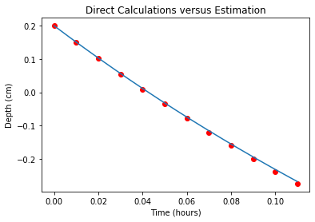

```python
plt.title('Direct Calculations versus Estimation')
plt.xlabel('Time (hours)')
plt.ylabel('Depth (cm)')
plt.plot(Appx_X,Appx_Y, 'ro')
# plt.annotate('Note: At 10th step, approximation is VALUE off from actual',
#              xy=(0.09, -0.2), xytext=(.095, -0.1), arrowprops=dict(
#              facecolor='black', shrink=0.05), horizontalalignment='right',
#              verticalalignment='bottom')
plt.plot(t, h(t))
```

## Analysis of approximation errors:

```python
correct = []
errors = []
percents = []
actual = []

for value in Appx_X:
    actual = sol(value)
    correct.append(actual)

for direct, estimate in zip(correct, Appx_Y):
    difference = direct - estimate
    errors.append(difference)

for direct, difference in zip(correct, errors):
    pct_error = abs( (difference / direct) ) * 100
    percents.append(pct_error)
```

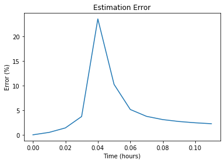

```python
plt.title('Estimation Error')
plt.xlabel('Time (hours)')
plt.ylabel('Error (%)')
plt.plot(Appx_X, percents)
```

## Twenty-year prediction:

As the substance should evaporate entirely in under three minutes, a twenty-year estimate obtained by either direct calculation, or Euler's method, will be impractical. The description provided of the behavior of the substance is inadequate for this time-scale, and more analysis on the substance would be required for a useful description of its behavior at this point.